# R Notebook

```r
library(tidyverse)
library(janitor)
```

```r
ames_data <- read_csv("data/ames.csv") %>%
  clean_names()
```

[output not shown]

Investigate the distribution of lot_area. Is the distribution roughly normal? If not, what problems do you find?

The data is right skewed.

```r
lot_area <- ames_data %>%
  summarise(
    mean_lot_area = mean(lot_area),
)

lot_area
```

| mean_lot_area |
| --- |
| 10147.92 |

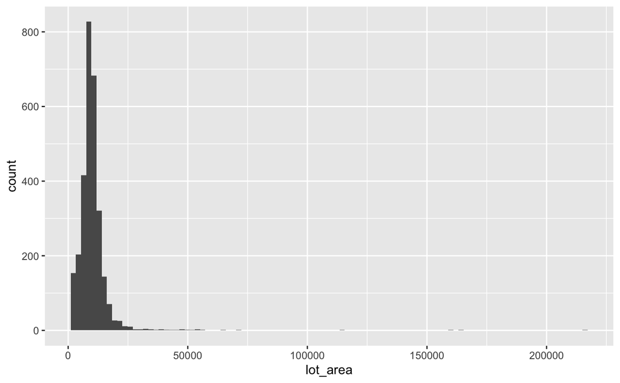

```r
ames_data %>%
  ggplot(aes(lot_area)) +
  geom_histogram(bins = 100)
```

```r
library(infer)
```

Compute and visualise a bootstrap sampling distribution for the mean(lot_area) of the sold houses.

```r
bootstrap_resample_200 <- ames_data %>%
  rep_sample_n(size = 200, replace = TRUE, reps = 5000) %>%
  summarise(
    mean_area = mean(lot_area)
  )
bootstrap_resample_200
```

| replicate | mean_area |
| --- | --- |
| 1 | 9893.750 |
| 2 | 9586.060 |
| 3 | 10005.245 |
| 4 | 9889.480 |
| 5 | 10285.445 |
| 6 | 9719.960 |
| 7 | 9659.480 |
| 8 | 10226.830 |
| 9 | 10132.055 |
| 10 | 9648.060 |

[output cut: 990 more lines]

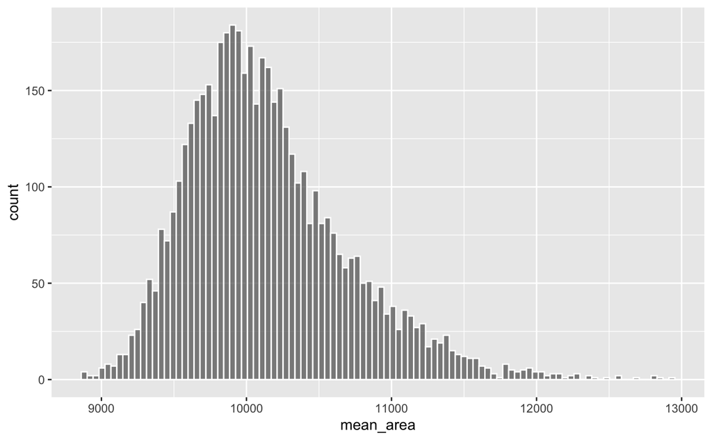

```r
bootstrap_resample_200 %>%
  ggplot(aes(mean_area)) +
  geom_histogram(col = "white", alpha = 0.7, bins = 100)
```

```r
infer_resample <- ames_data %>%
  specify(response = lot_area) %>%
  generate(reps = 5000, type = "bootstrap") %>%
  calculate(stat = "mean")
```

```r
infer_ci_95 <- infer_resample %>%
  get_confidence_interval(level = 0.95, type = "percentile")

infer_ci_95
```

| lower_ci | upper_ci |
| --- | --- |
| 9880.16 | 10447.32 |

You would like to know the mean(lot_area) of the sold houses with higher confidence. Calculate the 99% CI for this variable (you can re-use your bootstrap distribution from above). Is it narrower or broader than the 95% CI? Does that make sense?

```r
infer_ci_99 <- infer_resample %>%
  get_confidence_interval(level = 0.99, type = "percentile")

infer_ci_99
```

| lower_ci | upper_ci |
| --- | --- |
| 9797.995 | 10555.14 |

It is broader. This makes sense because the confidence interval is wider and more of the data falls between these two values and the areas outwith the confidence intervals is smaller.

Calculate the point estimate of the mean(lot_area)

```r
ames_data %>%
  summarise(point_est = mean(lot_area)
)
```

| point_est |
| --- |
| 10147.92 |

Calculate a point estimate and 95% CI for the proportion of houses in the data built before 1920. Does the number of reps you use matter? [Investigate reps from 200 up to 50000, memory of your laptop permitting].

```r
ames_filtered <- ames_data %>%
  filter(year_built <= 1920)
```

```r
bootstrap_resample_date <- ames_filtered %>%
  specify(response = year_built) %>%
  generate(reps = 50000, type = "bootstrap") %>%
  calculate(stat = "mean")
```

```r
year_ci_95 <- bootstrap_resample_date %>%
  get_confidence_interval(level = 0.95, type = "percentile")

year_ci_95
```

[output not shown]

```r
point_estimate_50000 <- ames_filtered %>%
  summarise(point_est = mean(year_built))
```